# Parne funkcie a ich vlastnosti

Maksym Shulika

2026-04-16

# Uvod: Co su to - parne funkcie?

Párne funkcie – prečo ich skúmať?

- Symetria podľa zvislej osi (Y)
- Zjednodušujú výpočty integrálov, derivácií a rozvojov
- Využitie vo fyzike, štatistike, spracovaní signálov

# Definicia

*Parne funkcie* - to su funkcie,ktore symmetricke cez nulu.

**Plati pre nu podmienka:**
$$f(−x)=f(x)$$

Pridavam niekolko prikladov parnych funkcii:

# Tabulka parnych funkcii:

Tabulka parnych funkcii

| number | func |
| --- | --- |
| 1 | $x^2$ |
| 2 | $x^4$ |
| 3 | $x^{100}$ |
| 4 | $$\mid x \mid$$ |
| 5 | $\cos(x)$ |
| 6 | $\frac{1}{x^2}$ |
| 7 | $x^4 - 5x^2 + 1$ |
| 8 | $e^{x^2}$ |
| 9 | $konstanta$ |

# Vlastnost’ #1.

Jedna z zauimavych vlastnosti parnych funkcii :

Ked’ integrujeme párnu funkciu na intervale

$[−a,a]$, výsledok je dvojnásobok integrálu na intervale

$[0,a]$.

## **Riešenie:**

$$\int_{-1}^{1} \frac{1}{x^2} \, dx = 2
\int_{0}^{1} \frac{1}{x^2} \, dx$$

# Vlastnost’ #2

**Este** jedna zauimava vlastnost: derivacia parnej funkcie **vzdy** bude neparna funkcia!

$$f(x) = x^2 \quad \text{(parna)}$$

$$f'(x) = 2x \quad \text{(neparna,
lebo } 2(-x) = -2x\text{)}$$

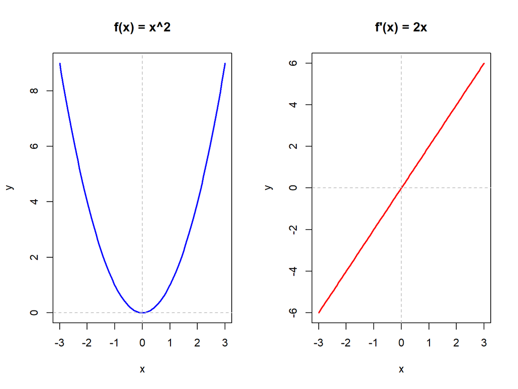

# Fourierove rady

**Fourierove rady** - sposob vyjadrit zlozitu funkciu s pomocou sumy $\sin$ a $\cos$ funkcii.

Ak je funkcia *parna*, v jej rozlozeni budu len kosinusy.

$$f(x) = |x| = \frac{\pi}{2} -
\frac{4}{\pi} \sum_{k=1}^{\infty} \frac{\cos((2k-1)x)}{(2k-1)^2}$$

# Vlastnost’

Este jedna z vlastnosti : **Ak funkcia parna,tak jej rozklad v Taylorovom rade bude mat** len **kratne mocniny**
$$f(x) = a_0 + a_2 x^2 + a_4 x^4 + \dots$$
**Priklad:**

$$\cos(x) = 1 - \frac{x^2}{2!} + \frac{x^4}{4!} - \dots$$

# Fyzicke priklady parnych funkcii

- Potencialova energia pruziny:
  $$\frac{kx^2}{2}$$
  .
- Intenzita difrakcneho obrazca

$$I(\theta) =
I_0(\frac{sin(\beta)}{\beta})^2$$

- Gaussova funkcia v optike (distribucia intenzity laseroveho luca):
  $$I(r) = I_0
  e^\frac{-2r^2}{w_0^2}$$

# 5. Zaver

*V projekte sme ukazali:*

- Definícia a príklady párnych funkcií
- Integrácia a derivácia
- Fourierove a Taylorove rady
- Aplikácie vo fyzike

# Zhrnutie:

Zhrnutie vlastnosi parnych funkcii

| vlastnosti | vzorce |
| --- | --- |
| Symetria | $f(-x) = f(x)$ |
| Integracia | $\int_{-a}^{a} f(x)dx = 2\int_0^a f(x)dx$ |
| Derivacia | $f'(x)$ je neparna |
| Fourierov rad | $b_n = 0$ (len kosinusy) |
| Plocha | plocha na $[-a,0]$ = plocha na $[0,a]$ |

# Zoznam literatury:

- [1] Wikipedia: *Even and odd functions* [online]. 2024 [cit. 2024-04-14]. Dostupne na: https://en.wikipedia.org/wiki/Even_and_odd_functions
- [2] RSTUDIO, 2024. *R Markdown: The Definitive Guide* [online]. Dostupne na: https://bookdown.org/yihui/rmarkdown/
- [3] WEISSSTEIN, Eric. *Even Function*. https://mathworld.wolfram.com/EvenFunction.html.
- [4] BORN, Max a WOLF, Emil, 2019. Principles of Optics: Electromagnetic Theory of Propagation, Interference and Diffraction of Light. 60th anniversary edition. Cambridge: Cambridge University Press. ISBN 978-1-108-47743-7.
- [5]ZORICH, Vladimir A., 2004. Mathematical Analysis I. Berlin: Springer. ISBN 3-540-40386-8. Dostupne na: https://zr9558.com/wp-content/uploads/2013/11/mathematical-analysis-zorich1.pdf
- [6] DeepSeek AI. Dostupne na: https://chat.deepseek.com.